# individual1

Molly Buckler

9/28/2020

##My partner and I did the lab idividually because in the email that was sent out it said we could.

```r
library(ggplot2)
library(classdata)
library(plyr)
library(dplyr)
library(readxl) # install.packages('readxl')
library(tidyverse)
install.packages('readxl',repos = "http://cran.us.r-project.org")
dat <- readxl::read_xls('life.tar/life/GSS.xls')
```

##Find the average years of education for the respondents with each political party affiliation. Arrange your output in a meaningful order and print. Describe any patterns you find.

```r
head(dat)
```

```
## # A tibble: 6 x 12
##   `Gss year for t~ `Importance of ~ `General happin~ `Political part~
##              <dbl> <chr>            <chr>            <chr>
## 1             1972 Not applicable   Not too happy    Ind,near dem
## 2             1972 Not applicable   Not too happy    Not str democrat
## 3             1972 Not applicable   Pretty happy     Independent
## 4             1972 Not applicable   Not too happy    Not str democrat
## 5             1972 Not applicable   Pretty happy     Strong democrat
## 6             1972 Not applicable   Pretty happy     Ind,near dem
## # ... with 8 more variables: `Respondents sex` <chr>, `Spouse diploma, ged, or
## #   other` <chr>, `Diploma, ged, or other` <chr>, `College major 1` <chr>,
## #   `Highest year of school completed` <chr>, `Marital status` <chr>,
## #   `Respondent id number` <dbl>, `Ballot used for interview` <chr>
```

```r
dat$`Highest year of school completed` <- as.numeric(as.character(dat$`Highest year of school completed`))
mYearEdPol <- aggregate( `Highest year of school completed` ~ `Political party affiliation`, dat, mean )
mYearEdPol
```

```
##    Political party affiliation Highest year of school completed
## 1                   Don't know                         10.90909
## 2                 Ind,near dem                         13.20671
## 3                 Ind,near rep                         13.29531
## 4                  Independent                         12.31946
## 5                    No answer                         12.27913
## 6             Not str democrat                         12.61759
## 7           Not str republican                         13.25678
## 8                  Other party                         13.43324
## 9              Strong democrat                         12.47403
## 10           Strong republican                         13.44067
```

```r
oMYearEdPol <- mYearEdPol[order(-mYearEdPol$`Highest year of school completed`),]
oMYearEdPol
```

```
##    Political party affiliation Highest year of school completed
## 10           Strong republican                         13.44067
## 8                  Other party                         13.43324
## 3                 Ind,near rep                         13.29531
## 7           Not str republican                         13.25678
## 2                 Ind,near dem                         13.20671
## 6             Not str democrat                         12.61759
## 9              Strong democrat                         12.47403
## 4                  Independent                         12.31946
## 5                    No answer                         12.27913
## 1                   Don't know                         10.90909
```

##The average for highest year of school completed was highest in the category “strong republican” and it was lowest in the category “don’t know”

##Create a single data frame containing records for the better educated respondents in each political party affiliation. A “better educated” respondent is someone who has strictly more years of education than the median in the same party affiliation. Print the structure of the data frame.

```r
betterEd <- filter(dat, `Highest year of school completed` > 13)
head(betterEd)
```

```
## # A tibble: 6 x 12
##   `Gss year for t~ `Importance of ~ `General happin~ `Political part~
##              <dbl> <chr>            <chr>            <chr>
## 1             1972 Not applicable   Not too happy    Ind,near dem
## 2             1972 Not applicable   Not too happy    Not str democrat
## 3             1972 Not applicable   Pretty happy     Ind,near dem
## 4             1972 Not applicable   Not too happy    Ind,near dem
## 5             1972 Not applicable   Not too happy    Strong democrat
## 6             1972 Not applicable   Very happy       Ind,near rep
## # ... with 8 more variables: `Respondents sex` <chr>, `Spouse diploma, ged, or
## #   other` <chr>, `Diploma, ged, or other` <chr>, `College major 1` <chr>,
## #   `Highest year of school completed` <dbl>, `Marital status` <chr>,
## #   `Respondent id number` <dbl>, `Ballot used for interview` <chr>
```

##How is the happiness of a respondent related to his/her marriage status? Define that a person is happy if the response to question is “Very happy” or “Pretty happy”.

```r
dat2 <- dat  %>% group_by(`Marital status`) %>% count(`General happiness`)
dat2
```

```
## # A tibble: 37 x 3
## # Groups:   Marital status [7]
##    `Marital status` `General happiness`     n
##    <chr>            <chr>               <int>
##  1 Divorced         Don't know              3
##  2 Divorced         No answer              58
##  3 Divorced         Not applicable        688
##  4 Divorced         Not too happy        1450
##  5 Divorced         Pretty happy         4683
##  6 Divorced         Very happy           1497
##  7 Married          Don't know             12
##  8 Married          No answer             123
##  9 Married          Not applicable       2221
## 10 Married          Not too happy        2431
## # ... with 27 more rows
```

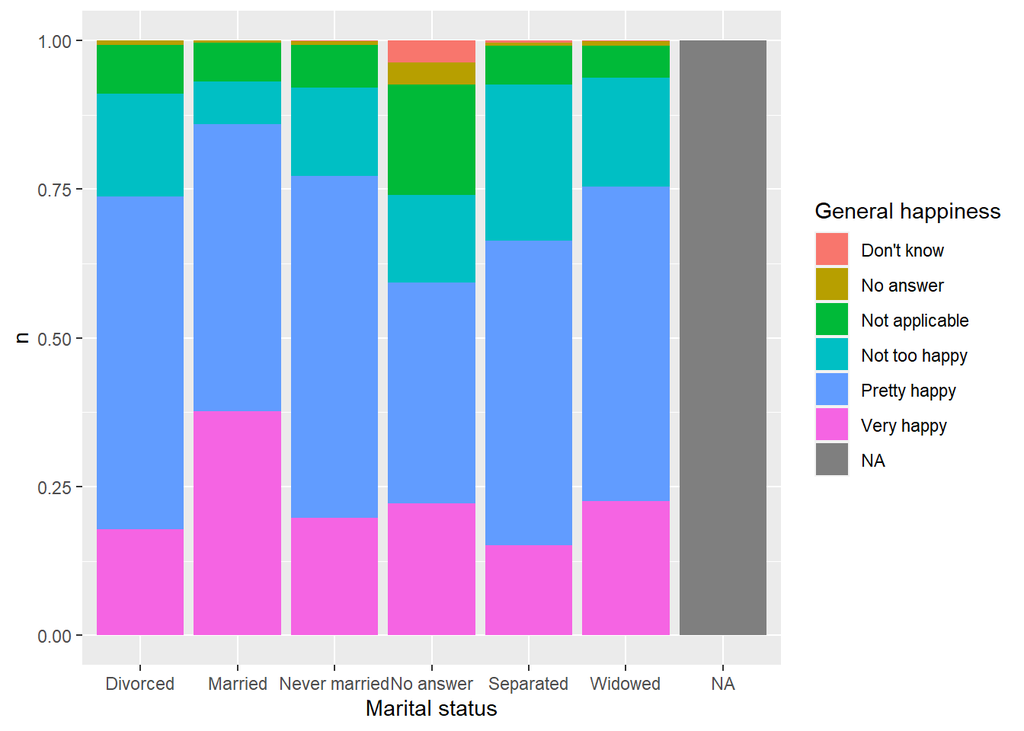

```r
ggplot(dat2, aes(fill=`General happiness`, y=n, x=`Marital status`)) +
    geom_bar(position="fill", stat="identity")
```

##As shown in the graph relationship status does have an effect on general happiness. The graph shows the percentage of general happiness based on marital status. Married people have the highest happiness percent happy when you combine “very happy” and “pretty happy” and seperated has the lowest percent happy when you combine “very happy” and “pretty happy”.

##Does party affiliation affect the relationship you found in the last question?

```r
dat3 <- dat %>% group_by(`Political party affiliation`) %>% count(`General happiness`)
dat3
```

```
## # A tibble: 57 x 3
## # Groups:   Political party affiliation [11]
##    `Political party affiliation` `General happiness`     n
##    <chr>                         <chr>               <int>
##  1 Don't know                    Not too happy           3
##  2 Don't know                    Pretty happy            3
##  3 Don't know                    Very happy              5
##  4 Ind,near dem                  Don't know              4
##  5 Ind,near dem                  No answer              38
##  6 Ind,near dem                  Not applicable        438
##  7 Ind,near dem                  Not too happy        1064
##  8 Ind,near dem                  Pretty happy         4324
##  9 Ind,near dem                  Very happy           1924
## 10 Ind,near rep                  Don't know              4
## # ... with 47 more rows
```

```r
dat3order <- dat3[order(-dat3$`n`),]
dat3order
```

```
## # A tibble: 57 x 3
## # Groups:   Political party affiliation [11]
##    `Political party affiliation` `General happiness`     n
##    <chr>                         <chr>               <int>
##  1 Not str democrat              Pretty happy         7203
##  2 Strong democrat               Pretty happy         5224
##  3 Not str republican            Pretty happy         5187
##  4 Independent                   Pretty happy         5018
##  5 Ind,near dem                  Pretty happy         4324
##  6 Not str democrat              Very happy           3601
##  7 Not str republican            Very happy           3267
##  8 Ind,near rep                  Pretty happy         3033
##  9 Strong democrat               Very happy           2955
## 10 Strong republican             Pretty happy         2837
## # ... with 47 more rows
```

##Not strong democrat with pretty happy has the highest count.

##How is marital status related to the education of a respondent? What are possible reasons accounting for the patterns you see?

```r
mYearEdMart <- aggregate( `Highest year of school completed` ~ `Marital status`, dat, mean )
mYearEdMart
```

```
##   Marital status Highest year of school completed
## 1       Divorced                         13.10582
## 2        Married                         12.96828
## 3  Never married                         13.38954
## 4      No answer                         15.47826
## 5      Separated                         11.85580
## 6        Widowed                         11.19825
```

```r
oMYearEdMart <- mYearEdMart[order(-mYearEdMart$`Highest year of school completed`),]
oMYearEdMart
```

```
##   Marital status Highest year of school completed
## 4      No answer                         15.47826
## 3  Never married                         13.38954
## 1       Divorced                         13.10582
## 2        Married                         12.96828
## 5      Separated                         11.85580
## 6        Widowed                         11.19825
```

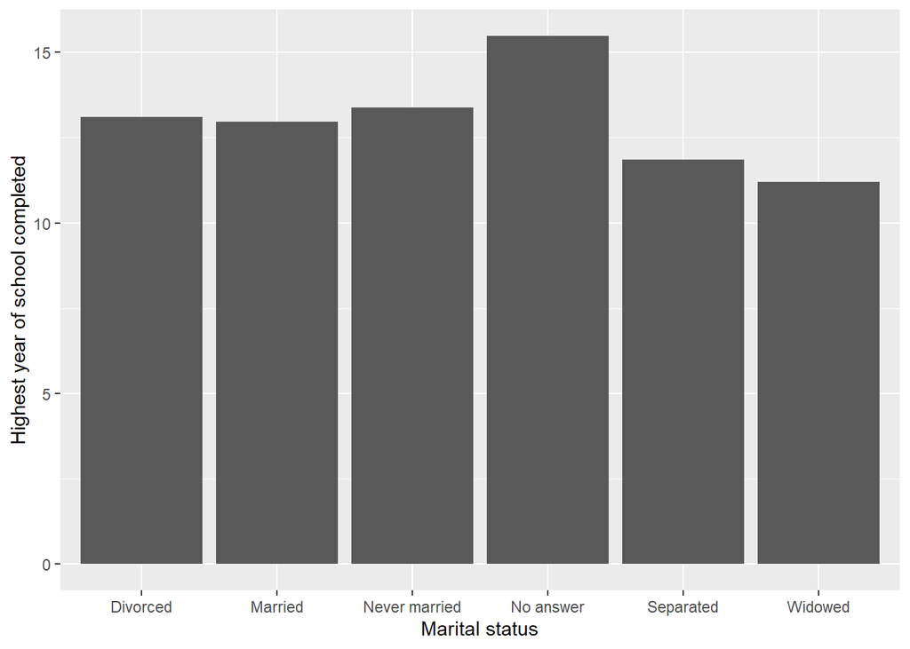

```r
p<-ggplot(data=oMYearEdMart, aes(x=`Marital status`, y=`Highest year of school completed`)) +
  geom_bar(stat="identity")
p
```

##The possible reasons for the pattern that is shown is that people never married is second highest because people with more education would not get married for reasons such as finish school or focussing on a career, people with more education typically have higher paying jobs and there for don’t need duel income so they may see it as not as nessessary to get married. Divorced comes in with the third highest. The reason for this pattern may be due to people with higher education typically make more money and it cost a fair amount to get divorced so it is a easier option for some more than others. I couldn’t come up with a reason why widowed would have the lowest education level.

##Explore two more interesting questions, and answer those questions using the GSS data.

```r
mYearEdSex <- aggregate( `Highest year of school completed` ~ `Respondents sex`, dat, mean )
mYearEdSex
```

```
##   Respondents sex Highest year of school completed
## 1          Female                         12.77199
## 2            Male                         12.99324
```

```r
oMYearEdSex <- mYearEdSex[order(-mYearEdSex$`Highest year of school completed`),]
oMYearEdSex
```

```
##   Respondents sex Highest year of school completed
## 2            Male                         12.99324
## 1          Female                         12.77199
```

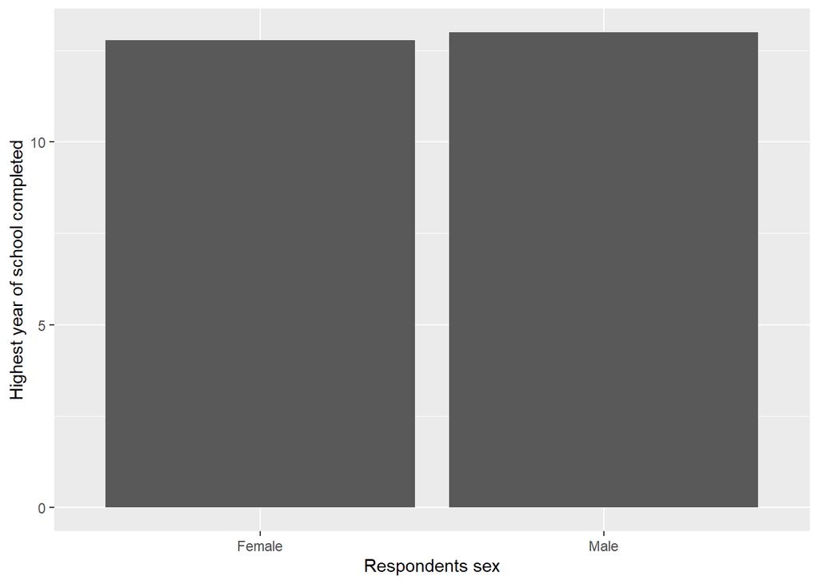

```r
a<-ggplot(data=oMYearEdSex, aes(x=`Respondents sex`, y=`Highest year of school completed`)) +
  geom_bar(stat="identity")
a
```

##I choose to look at the relationship between sex and highest year of school completed. Males on average have slightly higher years of school completed with males at 12.99 and females at 12.77. The reason for this pattern is that males are more likely to attend more school in order to get a higher paying job.

```r
sexPol <- dat  %>% group_by(`Respondents sex`) %>% count(`Political party affiliation`)
sexPol
```

```
## # A tibble: 21 x 3
## # Groups:   Respondents sex [3]
##    `Respondents sex` `Political party affiliation`     n
##    <chr>             <chr>                         <int>
##  1 Female            Don't know                        5
##  2 Female            Ind,near dem                   4086
##  3 Female            Ind,near rep                   2716
##  4 Female            Independent                    5561
##  5 Female            No answer                       245
##  6 Female            Not str democrat               8084
##  7 Female            Not str republican             5468
##  8 Female            Other party                     479
##  9 Female            Strong democrat                6244
## 10 Female            Strong republican              3312
## # ... with 11 more rows
```

```r
sexPolOrder <- sexPol[order(-sexPol$`n`),]
sexPolOrder
```

```
## # A tibble: 21 x 3
## # Groups:   Respondents sex [3]
##    `Respondents sex` `Political party affiliation`     n
##    <chr>             <chr>                         <int>
##  1 Female            Not str democrat               8084
##  2 Female            Strong democrat                6244
##  3 Female            Independent                    5561
##  4 Female            Not str republican             5468
##  5 Male              Not str democrat               5210
##  6 Male              Not str republican             4465
##  7 Male              Independent                    4327
##  8 Male              Strong democrat                4134
##  9 Female            Ind,near dem                   4086
## 10 Male              Ind,near dem                   3706
## # ... with 11 more rows
```

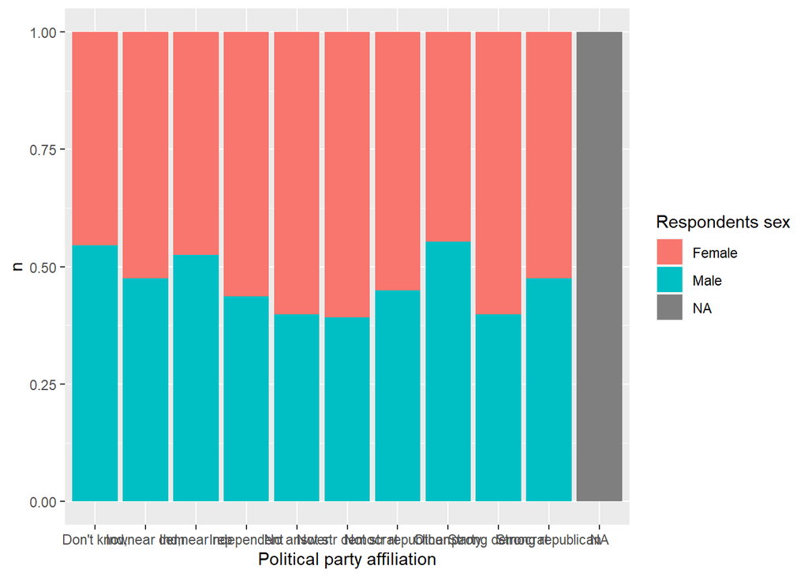

```r
ggplot(sexPol, aes(fill=`Respondents sex`, y=n, x=`Political party affiliation`)) +
    geom_bar(position="fill", stat="identity")
```

##This shows that females have the most of not strong democrats. The graph shows the percentage of females vs male in each category of political party affiliation.

}